# Unsupervised_Project

Michela Mazzaglia

2023-07-03

```r
library(ggplot2)
library(tree)
library(ISLR)
library(gbm)
library(JOUSBoost)
library(rpart)
library(nnet)
library(tidyverse)
library(dplyr)
library(corrplot)
library(ggthemes)
library(mapsf)
library(viridis)
library(readr)
library(caret)
library(tibble)
library(MASS)
library(class)
library(maps)
library(cluster)
library(gower)
library(factoextra)
library(VIM)
library(psych)
library(FactoMineR)
library(proxy)
library(klaR)
library(readxl)
```

# IMPORT DATA

```r
my_ds1 <- read_xlsx("C:/Users/miche/OneDrive/Desktop/My_DS.xlsx")
head(my_ds1)
```

```
## # A tibble: 6 × 11
##   VARIABLE  Life expectancy at b…¹ Share of people with…² Exposure to air poll…³
##   <chr>                      <dbl>                  <dbl>                  <dbl>
## 1 GEO (Lab…                   NA                     NA                     NA
## 2 European…                   77.2                   69                     12.6
## 3 Belgium                     79.4                   76.4                   11.1
## 4 Bulgaria                    68                     67.6                   19.6
## 5 Czechia                     74.1                   67.8                   14.4
## 6 Denmark                     79.6                   67                     10
## # ℹ abbreviated names: ¹`Life expectancy at birth by sex`,
## #   ²`Share of people with good or very good perceived health by sex`,
## #   ³`Exposure to air pollution by particulate matter (source: EEA)`
## # ℹ 7 more variables:
## #   `Self-perceived health by sex, age and income quintile` <dbl>,
## #   `Depressive symptoms` <dbl>, `Average rating of life satisfaction` <dbl>,
## #   `Employment rates` <dbl>, `Trust in the legal system` <dbl>, …
```

## DATA CLEANING

```r
my_ds <- my_ds1[-c(1, nrow(my_ds1)), ]
summary(my_ds)
```

```
##    VARIABLE         Life expectancy at birth by sex
##  Length:38          Min.   :68.00
##  Class :character   1st Qu.:73.15
##  Mode  :character   Median :78.80
##                     Mean   :76.86
##                     3rd Qu.:80.45
##                     Max.   :81.80
##                     NA's   :7
##  Share of people with good or very good perceived health by sex
##  Min.   :47.90
##  1st Qu.:64.70
##  Median :69.05
##  Mean   :68.41
##  3rd Qu.:73.05
##  Max.   :81.90
##  NA's   :6
##  Exposure to air pollution by particulate matter (source: EEA)
##  Min.   : 4.80
##  1st Qu.: 9.60
##  Median :11.10
##  Mean   :11.61
##  3rd Qu.:14.25
##  Max.   :19.60
##  NA's   :7
##  Self-perceived health by sex, age and income quintile Depressive symptoms
##  Min.   : 4.70                                         Min.   : 2.200
##  1st Qu.:17.35                                         1st Qu.: 4.725
##  Median :21.60                                         Median : 6.350
##  Mean   :23.81                                         Mean   : 6.375
##  3rd Qu.:27.85                                         3rd Qu.: 8.325
##  Max.   :53.80                                         Max.   :10.800
##  NA's   :3                                             NA's   :6
##  Average rating of life satisfaction Employment rates Trust in the legal system
##  Min.   :5.600                       Min.   :58.50    Min.   :2.700
##  1st Qu.:6.800                       1st Qu.:71.60    1st Qu.:3.700
##  Median :7.200                       Median :74.70    Median :4.900
##  Mean   :7.103                       Mean   :74.75    Mean   :4.871
##  3rd Qu.:7.500                       3rd Qu.:79.50    3rd Qu.:5.600
##  Max.   :8.000                       Max.   :88.20    Max.   :7.500
##  NA's   :7                           NA's   :9        NA's   :3
##  Crime, violence or vandalism in the area Social support
##  Length:38                                Min.   :86.80
##  Class :character                         1st Qu.:93.10
##  Mode  :character                         Median :95.75
##                                           Mean   :94.66
##                                           3rd Qu.:96.78
##                                           Max.   :98.10
##                                           NA's   :4
```

```r
anyNA(my_ds)
```

```
## [1] TRUE
```

```r
my_ds <- na.omit(my_ds)
head(my_ds)
```

```
## # A tibble: 6 × 11
##   VARIABLE Life expectancy at bi…¹ Share of people with…² Exposure to air poll…³
##   <chr>                      <dbl>                  <dbl>                  <dbl>
## 1 Belgium                     79.4                   76.4                   11.1
## 2 Czechia                     74.1                   67.8                   14.4
## 3 Denmark                     79.6                   67                     10
## 4 Germany                     78.4                   63                     10.9
## 5 Estonia                     72.7                   58.3                    4.8
## 6 Ireland                     80.5                   81.2                    8.8
## # ℹ abbreviated names: ¹`Life expectancy at birth by sex`,
## #   ²`Share of people with good or very good perceived health by sex`,
## #   ³`Exposure to air pollution by particulate matter (source: EEA)`
## # ℹ 7 more variables:
## #   `Self-perceived health by sex, age and income quintile` <dbl>,
## #   `Depressive symptoms` <dbl>, `Average rating of life satisfaction` <dbl>,
## #   `Employment rates` <dbl>, `Trust in the legal system` <dbl>, …
```

```r
my_ds <- my_ds %>% dplyr::select(-c())
cn <- c("Country", "Life_expectancy","Share_of_perceived_health","Air_pollution","Self_perceived_health","Depressive_symptoms","Life_satisfaction","Employment_rates","Trust","Crime_levels", "Social_support")
colnames(my_ds) <- cn
rm(cn)
```

# EXPLANATORY DATA ANALYSIS

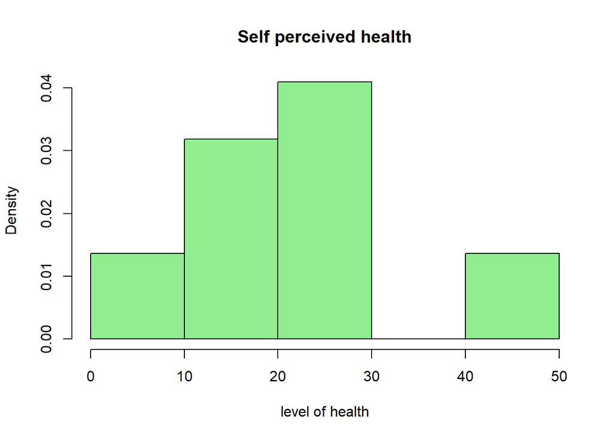

```r
hist(my_ds$Self_perceived_health, freq =F, col = "light green", main = "Self perceived health",
     xlab = "level of health")
```

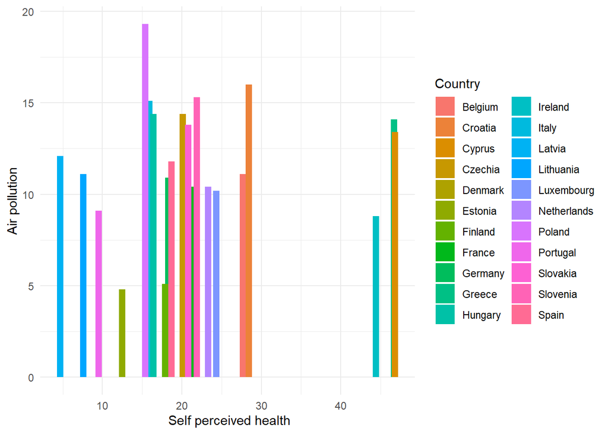

```r
ggplot(my_ds, aes(x = Self_perceived_health, y = Air_pollution, fill = Country)) +
  geom_bar(stat = "identity", width = 0.8) +
  labs(x = " Self perceived health", y = "Air pollution") +
  theme_minimal()
```

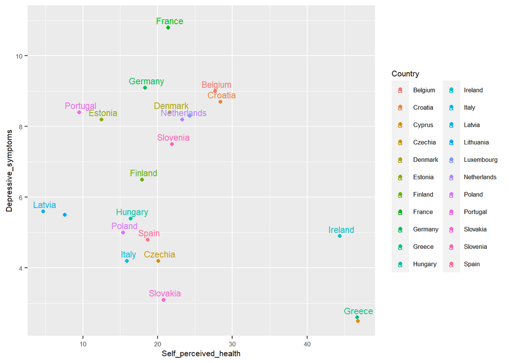

```r
ggplot(
  data = my_ds,
  mapping = aes(x = Self_perceived_health, y = Depressive_symptoms, label = Country, color = Country)) +
  geom_point() +
  geom_text(size = 3, nudge_x = 0.20, nudge_y = 0.20, check_overlap = TRUE) +
  theme(text = element_text(size = 8))
```

Life satisfaction levels per country

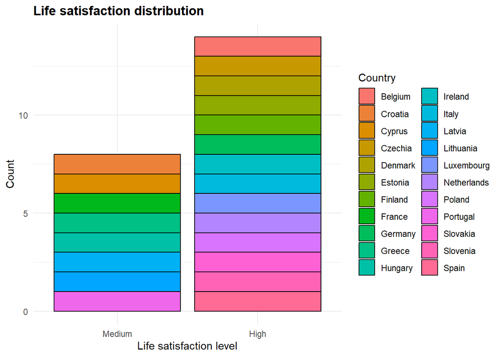

```r
my_ds$Life_satisfaction_levels <- cut(my_ds$Life_satisfaction, c(5, 6, 7, 8), labels = c("Low","Medium","High") )

ggplot(my_ds,aes(x= Life_satisfaction_levels, fill= Country))+
  geom_bar(col="black")+
 # facet_wrap(.~Country)+
  #stat_count(aes(y=..count.., label=..count..),geom="text", col="black")+
  labs(x="Life satisfaction level", y = "Count", title="Life satisfaction distribution", fill= "Country")+
  theme_minimal()+
  theme(plot.title=element_text(face="bold"))
```

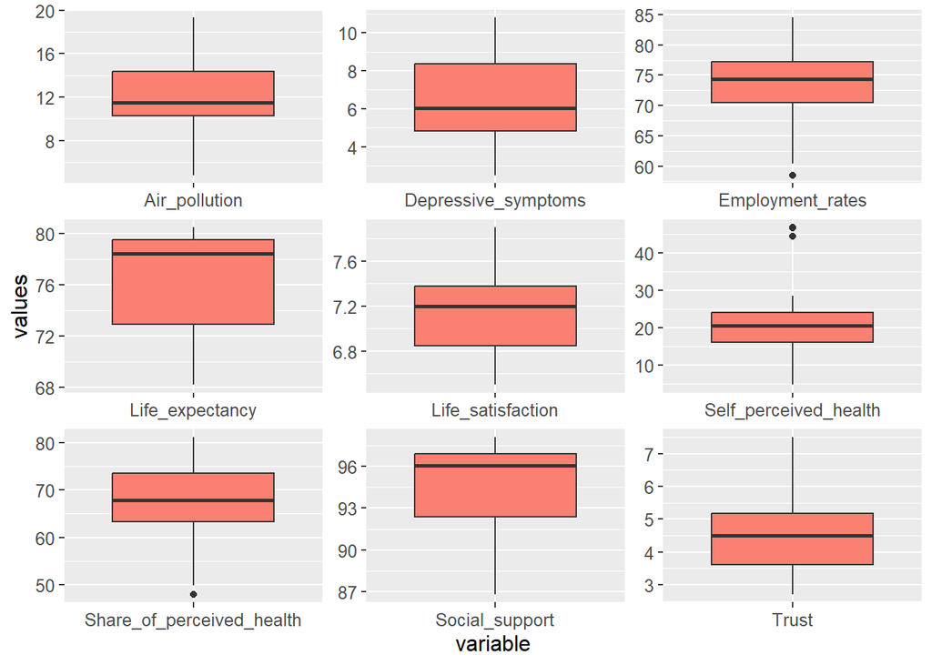

```r
data_num <- select_if(my_ds,is.numeric)
data_num_box <-data_num %>% gather(variable,values,1:9)

ggplot(data_num_box)+
  geom_boxplot(aes(x=variable,y=values), fill = "salmon") +
  facet_wrap(~variable,ncol=3,scales="free") +
  theme(strip.text.x = element_blank(),
        text = element_text(size=12))
```

```r
summary(boxplot.stats(my_ds$Share_of_perceived_health))
```

```
##       Length Class  Mode
## stats 5      -none- numeric
## n     1      -none- numeric
## conf  2      -none- numeric
## out   0      -none- numeric
```

```r
summary(boxplot.stats(my_ds$Life_expectancy))
```

```
##       Length Class  Mode
## stats 5      -none- numeric
## n     1      -none- numeric
## conf  2      -none- numeric
## out   0      -none- numeric
```

```r
summary(boxplot.stats(my_ds$Life_satisfaction))
```

```
##       Length Class  Mode
## stats 5      -none- numeric
## n     1      -none- numeric
## conf  2      -none- numeric
## out   0      -none- numeric
```

```r
summary(boxplot.stats(my_ds$Air_pollution))
```

```
##       Length Class  Mode
## stats 5      -none- numeric
## n     1      -none- numeric
## conf  2      -none- numeric
## out   0      -none- numeric
```

```r
summary(boxplot.stats(my_ds$Employment_rates))
```

```
##       Length Class  Mode
## stats 5      -none- numeric
## n     1      -none- numeric
## conf  2      -none- numeric
## out   1      -none- numeric
```

```r
summary(boxplot.stats(my_ds$Depressive_symptoms))
```

```
##       Length Class  Mode
## stats 5      -none- numeric
## n     1      -none- numeric
## conf  2      -none- numeric
## out   0      -none- numeric
```

```r
summary(boxplot.stats(my_ds$Self_perceived_health))
```

```
##       Length Class  Mode
## stats 5      -none- numeric
## n     1      -none- numeric
## conf  2      -none- numeric
## out   3      -none- numeric
```

```r
summary(boxplot.stats(my_ds$Social_support))
```

```
##       Length Class  Mode
## stats 5      -none- numeric
## n     1      -none- numeric
## conf  2      -none- numeric
## out   0      -none- numeric
```

```r
summary(boxplot.stats(my_ds$Trust))
```

```
##       Length Class  Mode
## stats 5      -none- numeric
## n     1      -none- numeric
## conf  2      -none- numeric
## out   0      -none- numeric
```

```r
rm(data_num_box)
```

I consider to not remove the outliers present in Self perceived health since we want to conduct the analysis on it

## Correlation

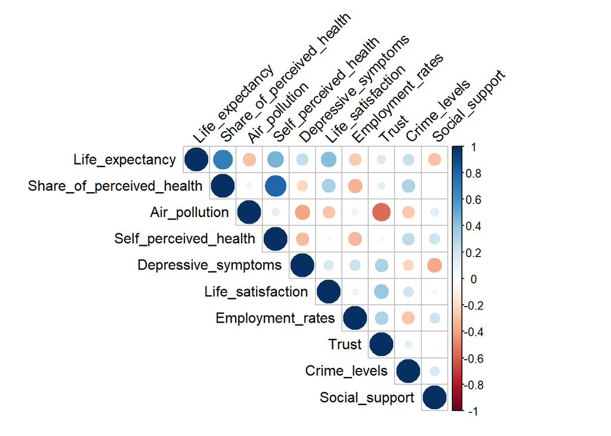

```r
my_ds <- my_ds %>% dplyr::select(-Life_satisfaction_levels, -Country)
my_ds$Crime_levels <- as.numeric(my_ds$Crime_levels)
correlation <- cor(my_ds)
corrplot(correlation,type = "upper", tl.col = "black",tl.srt = 45)
```

```r
rm(correlation)
```

# PCA

We do some data visualization with the Principal Component Analysis We delete the response variable since we are conducting a clustering analysis

```r
roll <- my_ds1[-c(1, nrow(my_ds1)), ]
summary(roll)
```

```
##    VARIABLE         Life expectancy at birth by sex
##  Length:38          Min.   :68.00
##  Class :character   1st Qu.:73.15
##  Mode  :character   Median :78.80
##                     Mean   :76.86
##                     3rd Qu.:80.45
##                     Max.   :81.80
##                     NA's   :7
##  Share of people with good or very good perceived health by sex
##  Min.   :47.90
##  1st Qu.:64.70
##  Median :69.05
##  Mean   :68.41
##  3rd Qu.:73.05
##  Max.   :81.90
##  NA's   :6
##  Exposure to air pollution by particulate matter (source: EEA)
##  Min.   : 4.80
##  1st Qu.: 9.60
##  Median :11.10
##  Mean   :11.61
##  3rd Qu.:14.25
##  Max.   :19.60
##  NA's   :7
##  Self-perceived health by sex, age and income quintile Depressive symptoms
##  Min.   : 4.70                                         Min.   : 2.200
##  1st Qu.:17.35                                         1st Qu.: 4.725
##  Median :21.60                                         Median : 6.350
##  Mean   :23.81                                         Mean   : 6.375
##  3rd Qu.:27.85                                         3rd Qu.: 8.325
##  Max.   :53.80                                         Max.   :10.800
##  NA's   :3                                             NA's   :6
##  Average rating of life satisfaction Employment rates Trust in the legal system
##  Min.   :5.600                       Min.   :58.50    Min.   :2.700
##  1st Qu.:6.800                       1st Qu.:71.60    1st Qu.:3.700
##  Median :7.200                       Median :74.70    Median :4.900
##  Mean   :7.103                       Mean   :74.75    Mean   :4.871
##  3rd Qu.:7.500                       3rd Qu.:79.50    3rd Qu.:5.600
##  Max.   :8.000                       Max.   :88.20    Max.   :7.500
##  NA's   :7                           NA's   :9        NA's   :3
##  Crime, violence or vandalism in the area Social support
##  Length:38                                Min.   :86.80
##  Class :character                         1st Qu.:93.10
##  Mode  :character                         Median :95.75
##                                           Mean   :94.66
##                                           3rd Qu.:96.78
##                                           Max.   :98.10
##                                           NA's   :4
```

```r
anyNA(roll)
```

```
## [1] TRUE
```

```r
roll <- na.omit(roll)
head(roll)
```

```
## # A tibble: 6 × 11
##   VARIABLE Life expectancy at bi…¹ Share of people with…² Exposure to air poll…³
##   <chr>                      <dbl>                  <dbl>                  <dbl>
## 1 Belgium                     79.4                   76.4                   11.1
## 2 Czechia                     74.1                   67.8                   14.4
## 3 Denmark                     79.6                   67                     10
## 4 Germany                     78.4                   63                     10.9
## 5 Estonia                     72.7                   58.3                    4.8
## 6 Ireland                     80.5                   81.2                    8.8
## # ℹ abbreviated names: ¹`Life expectancy at birth by sex`,
## #   ²`Share of people with good or very good perceived health by sex`,
## #   ³`Exposure to air pollution by particulate matter (source: EEA)`
## # ℹ 7 more variables:
## #   `Self-perceived health by sex, age and income quintile` <dbl>,
## #   `Depressive symptoms` <dbl>, `Average rating of life satisfaction` <dbl>,
## #   `Employment rates` <dbl>, `Trust in the legal system` <dbl>, …
```

```r
roll <- roll %>% dplyr::select(-c())
cn <- c("Country", "Life_expectancy","Share_of_perceived_health","Air_pollution","Self_perceived_health","Depressive_symptoms","Life_satisfaction","Employment_rates","Trust","Crime_levels", "Social_support")
colnames(roll) <- cn
rm(cn)
roll <- roll %>% dplyr::select(-Self_perceived_health)
```

Number of rows and columns

```r
nrow(roll)
```

```
## [1] 22
```

```r
ncol(roll)
```

```
## [1] 10
```

mean and std

```r
roll <- roll %>%
  mutate(Life_expectancy = as.numeric(Life_expectancy),
         Share_of_perceived_health = as.numeric(Share_of_perceived_health),
         Air_pollution = as.numeric(Air_pollution),
         Depressive_symptoms = as.numeric(Depressive_symptoms),
         Life_satisfaction = as.numeric(Life_satisfaction),
         Employment_rates = as.numeric(Employment_rates),
         Trust = as.numeric(Trust),
         Crime_levels = as.numeric(Crime_levels),
         Social_support = as.numeric(Social_support))
my_ds <- my_ds %>% dplyr::select(-Self_perceived_health)
means <- colMeans(my_ds)
means
```

```
##           Life_expectancy Share_of_perceived_health             Air_pollution
##                 76.454545                 67.090909                 11.890909
##       Depressive_symptoms         Life_satisfaction          Employment_rates
##                  6.404545                  7.159091                 73.400000
##                     Trust              Crime_levels            Social_support
##                  4.577273                  9.318182                 94.477273
```

```r
std <- apply(my_ds, 2, sd)
std
```

```
##           Life_expectancy Share_of_perceived_health             Air_pollution
##                 4.1201858                 9.2442986                 3.4086597
##       Depressive_symptoms         Life_satisfaction          Employment_rates
##                 2.3649177                 0.3403907                 6.6677618
##                     Trust              Crime_levels            Social_support
##                 1.2783664                 4.8141296                 3.3841271
```

We use the code of the book

```r
pr.out=prcomp(my_ds, scale=TRUE)
names(pr.out)
```

```
## [1] "sdev"     "rotation" "center"   "scale"    "x"
```

```r
pr.out$center
```

```
##           Life_expectancy Share_of_perceived_health             Air_pollution
##                 76.454545                 67.090909                 11.890909
##       Depressive_symptoms         Life_satisfaction          Employment_rates
##                  6.404545                  7.159091                 73.400000
##                     Trust              Crime_levels            Social_support
##                  4.577273                  9.318182                 94.477273
```

```r
pr.out$scale
```

```
##           Life_expectancy Share_of_perceived_health             Air_pollution
##                 4.1201858                 9.2442986                 3.4086597
##       Depressive_symptoms         Life_satisfaction          Employment_rates
##                 2.3649177                 0.3403907                 6.6677618
##                     Trust              Crime_levels            Social_support
##                 1.2783664                 4.8141296                 3.3841271
```

```r
pr.out$rotation
```

```
##                                   PC1         PC2         PC3         PC4
## Life_expectancy           -0.49329376 -0.22395460  0.21844783 -0.18550031
## Share_of_perceived_health -0.34259972 -0.46436857 -0.02553516 -0.35645612
## Air_pollution              0.40143086 -0.29708584  0.13056726 -0.48482198
## Depressive_symptoms       -0.25619855  0.44197796  0.34949820  0.03331496
## Life_satisfaction         -0.42433965  0.02226401 -0.15951717 -0.38072640
## Employment_rates           0.07169879  0.48891388 -0.28612439 -0.41844137
## Trust                     -0.36787463  0.33446374 -0.31630006 -0.02170481
## Crime_levels              -0.24443979 -0.30490729 -0.38445154  0.51280970
## Social_support             0.17948499 -0.07896033 -0.67621749 -0.13738909
##                                   PC5         PC6         PC7         PC8
## Life_expectancy            0.25920865  0.33408179  0.08449408  0.29361602
## Share_of_perceived_health  0.35397714 -0.09607551  0.11234331 -0.13595632
## Air_pollution             -0.13883816 -0.02031352  0.15161947 -0.57353541
## Depressive_symptoms        0.04051805  0.52008275 -0.13429500 -0.53824335
## Life_satisfaction         -0.75946303 -0.04742907 -0.25171391  0.06849352
## Employment_rates           0.03947448  0.17163969  0.65160779  0.19091974
## Trust                      0.30509510 -0.56582660 -0.08558414 -0.36843280
## Crime_levels              -0.25186884  0.20590233  0.47739293 -0.31391357
## Social_support             0.22744239  0.46259587 -0.46479550 -0.03507954
##                                   PC9
## Life_expectancy           -0.59348665
## Share_of_perceived_health  0.61126000
## Air_pollution             -0.35619251
## Depressive_symptoms        0.18944678
## Life_satisfaction          0.04423779
## Employment_rates           0.08246620
## Trust                     -0.30979879
## Crime_levels              -0.06499639
## Social_support            -0.04913390
```

The dataset transformed into a new set of variables (principal components)that capture the maximum amount of variation in the data The first component explains the most variability and so on…

```r
dim(pr.out$x)
```

```
## [1] 22  9
```

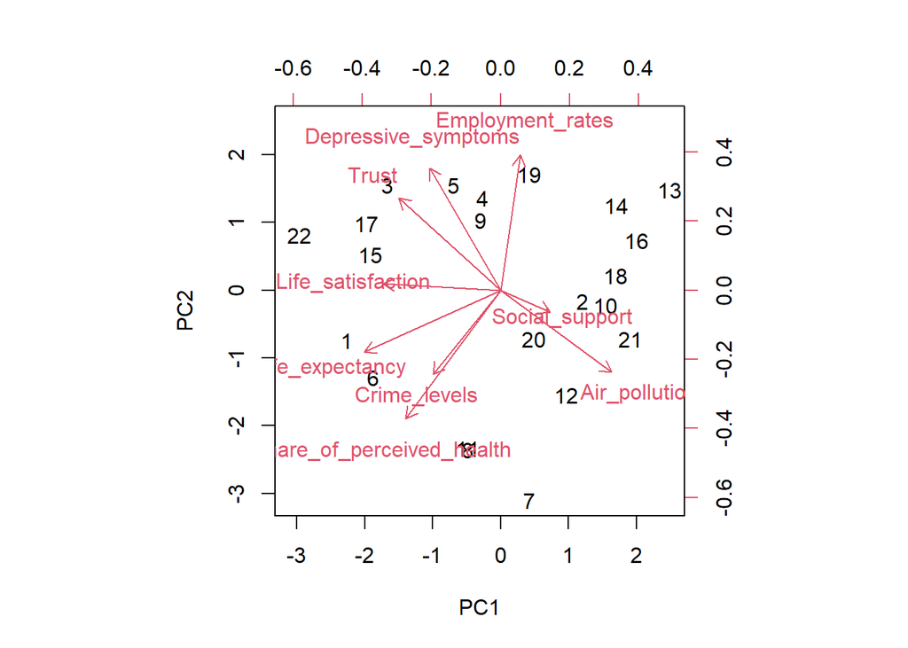

```r
biplot(pr.out, scale=0)
```

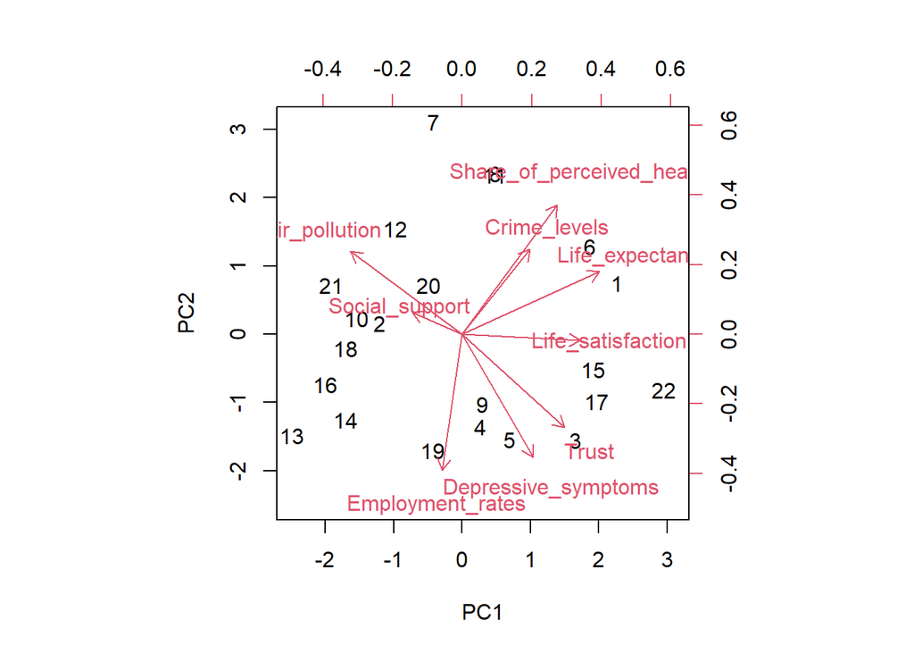

```r
pr.out$rotation=-pr.out$rotation
pr.out$x=-pr.out$x
biplot(pr.out, scale=0)
```

```r
pr.out$sdev
```

```
## [1] 1.6033532 1.4337101 1.1978701 0.9811930 0.7565692 0.7113052 0.6506560
## [8] 0.5985509 0.3407826
```

```r
pr.var=pr.out$sdev^2
pr.var
```

```
## [1] 2.5707416 2.0555247 1.4348928 0.9627396 0.5723970 0.5059551 0.4233533
## [8] 0.3582632 0.1161328
```

```r
pve=pr.var/sum(pr.var)
pve
```

```
## [1] 0.28563795 0.22839163 0.15943254 0.10697107 0.06359966 0.05621723 0.04703925
## [8] 0.03980702 0.01290364
```

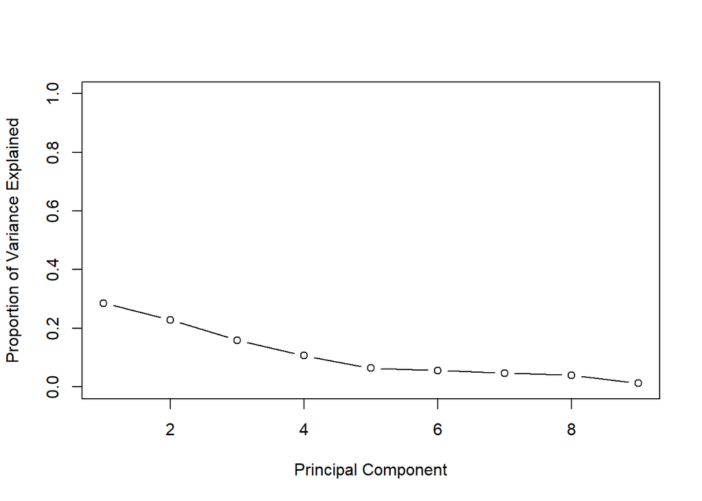

```r
plot(pve, xlab="Principal Component", ylab="Proportion of Variance Explained", ylim=c(0,1),type='b')
```

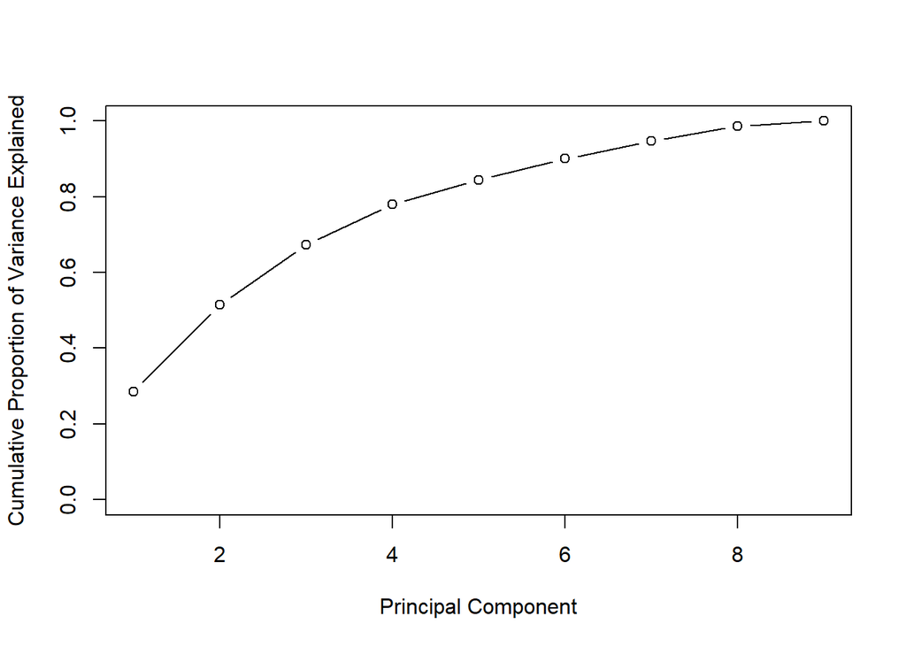

```r
plot(cumsum(pve), xlab="Principal Component", ylab="Cumulative Proportion of Variance Explained", ylim=c(0,1),type='b')
```

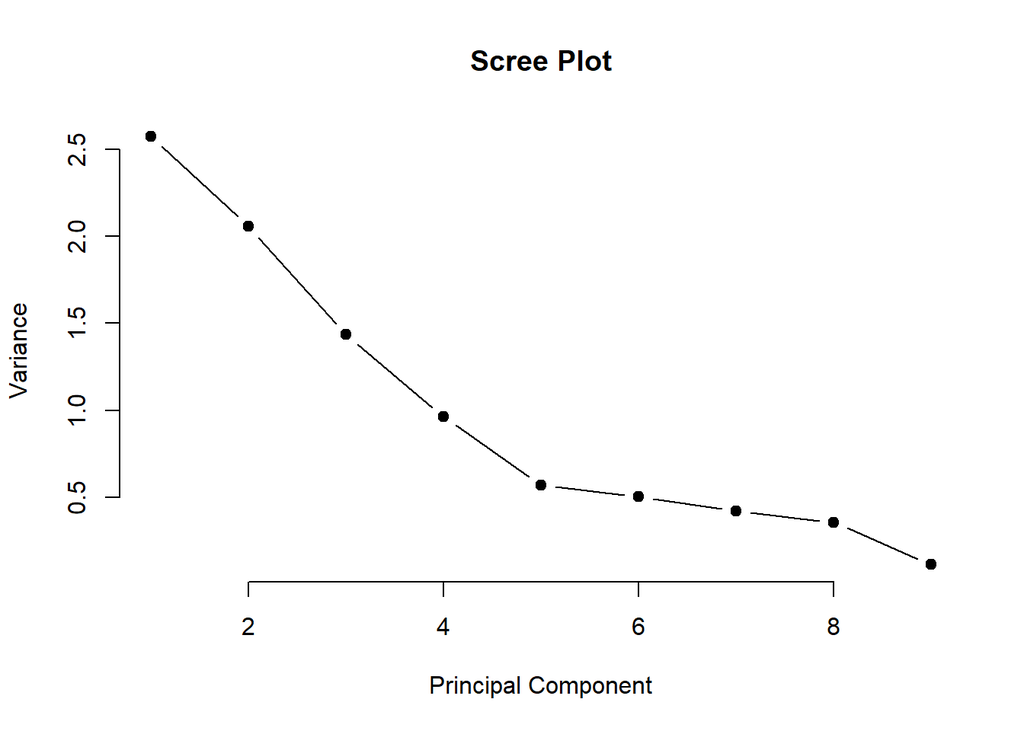

```r
plot(1:length(pr.out$sdev), pr.out$sdev^2,
     type = "b", pch = 19, frame = FALSE,
     xlab = "Principal Component", ylab = "Variance",
     main = "Scree Plot")
```

which components are the most relevant ones?

```r
rho <- cor(my_ds)
round(rho,3)
```

```
##                           Life_expectancy Share_of_perceived_health
## Life_expectancy                     1.000                     0.688
## Share_of_perceived_health           0.688                     1.000
## Air_pollution                      -0.299                     0.074
## Depressive_symptoms                 0.244                    -0.204
## Life_satisfaction                   0.420                     0.325
## Employment_rates                   -0.258                    -0.349
## Trust                               0.146                     0.105
## Crime_levels                        0.224                     0.317
## Social_support                     -0.284                    -0.011
##                           Air_pollution Depressive_symptoms Life_satisfaction
## Life_expectancy                  -0.299               0.244             0.420
## Share_of_perceived_health         0.074              -0.204             0.325
## Air_pollution                     1.000              -0.399            -0.275
## Depressive_symptoms              -0.399               1.000             0.179
## Life_satisfaction                -0.275               0.179             1.000
## Employment_rates                 -0.089               0.214             0.077
## Trust                            -0.568               0.314             0.376
## Crime_levels                     -0.262              -0.212             0.198
## Social_support                    0.127              -0.374            -0.056
##                           Employment_rates  Trust Crime_levels Social_support
## Life_expectancy                     -0.258  0.146        0.224         -0.284
## Share_of_perceived_health           -0.349  0.105        0.317         -0.011
## Air_pollution                       -0.089 -0.568       -0.262          0.127
## Depressive_symptoms                  0.214  0.314       -0.212         -0.374
## Life_satisfaction                    0.077  0.376        0.198         -0.056
## Employment_rates                     1.000  0.313       -0.278          0.201
## Trust                                0.313  1.000        0.109          0.016
## Crime_levels                        -0.278  0.109        1.000          0.168
## Social_support                       0.201  0.016        0.168          1.000
```

```r
eigen(rho)
```

```
## eigen() decomposition
## $values
## [1] 2.5707416 2.0555247 1.4348928 0.9627396 0.5723970 0.5059551 0.4233533
## [8] 0.3582632 0.1161328
##
## $vectors
##              [,1]        [,2]        [,3]        [,4]        [,5]        [,6]
##  [1,] -0.49329376  0.22395460  0.21844783  0.18550031  0.25920865 -0.33408179
##  [2,] -0.34259972  0.46436857 -0.02553516  0.35645612  0.35397714  0.09607551
##  [3,]  0.40143086  0.29708584  0.13056726  0.48482198 -0.13883816  0.02031352
##  [4,] -0.25619855 -0.44197796  0.34949820 -0.03331496  0.04051805 -0.52008275
##  [5,] -0.42433965 -0.02226401 -0.15951717  0.38072640 -0.75946303  0.04742907
##  [6,]  0.07169879 -0.48891388 -0.28612439  0.41844137  0.03947448 -0.17163969
##  [7,] -0.36787463 -0.33446374 -0.31630006  0.02170481  0.30509510  0.56582660
##  [8,] -0.24443979  0.30490729 -0.38445154 -0.51280970 -0.25186884 -0.20590233
##  [9,]  0.17948499  0.07896033 -0.67621749  0.13738909  0.22744239 -0.46259587
##              [,7]        [,8]        [,9]
##  [1,] -0.08449408  0.29361602  0.59348665
##  [2,] -0.11234331 -0.13595632 -0.61126000
##  [3,] -0.15161947 -0.57353541  0.35619251
##  [4,]  0.13429500 -0.53824335 -0.18944678
##  [5,]  0.25171391  0.06849352 -0.04423779
##  [6,] -0.65160779  0.19091974 -0.08246620
##  [7,]  0.08558414 -0.36843280  0.30979879
##  [8,] -0.47739293 -0.31391357  0.06499639
##  [9,]  0.46479550 -0.03507954  0.04913390
```

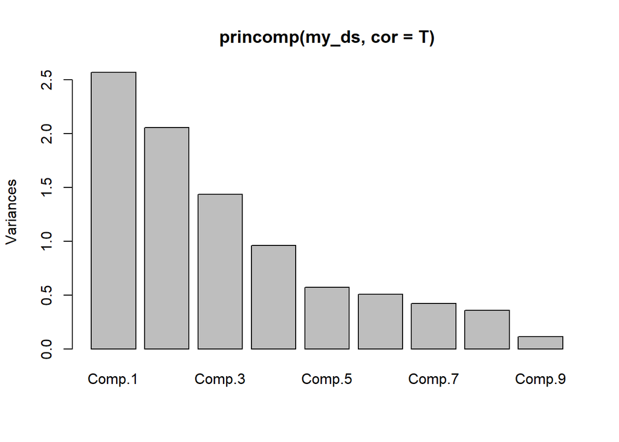

```r
screeplot(princomp(my_ds, cor=T))
```

# CLUSTERING

We use roll with the categorical variable Country

We need to standardise the distances to better ensure the predictability since the data have different scale/unit

```r
my_ds <- scale(my_ds)
```

```r
dist_matrix <- dist(my_ds, method = "euclidean")
```

```r
hc <- hclust(dist_matrix, method = "ward.D2")
```

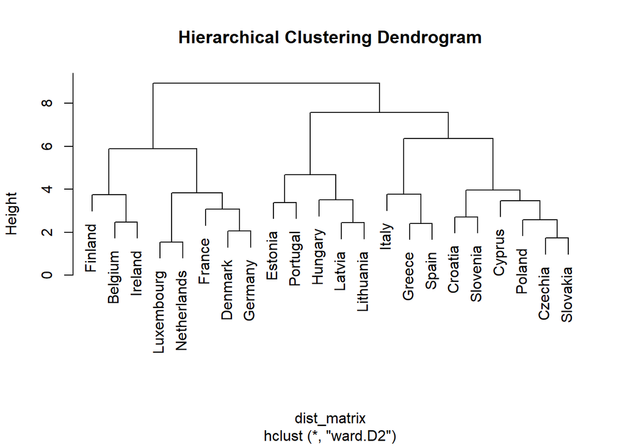

```r
plot(hc, main = "Hierarchical Clustering Dendrogram", labels = roll$Country)
```

We could use other distances calculating methods

```r
manhattan_dist <- dist(my_ds, method = "manhattan")
manhattan_dist
```

```
##            1         2         3         4         5         6         7
## 2  12.494998
## 3   8.639091  8.682726
## 4   8.437581  7.690081  4.642905
## 5   8.815900 11.010927  8.765465  7.661065
## 6   5.940027  9.633359  8.252134  8.769495 10.208325
## 7  11.013078  9.693321 13.942131 12.173806 13.987096  9.120148
## 8   7.718650  8.714180 10.921200 10.027437 12.034078  5.751369  6.883053
## 9   8.257702 11.143741  8.081805  5.743736  9.087687 11.334606 11.717955
## 10 11.001756  8.016443 10.373797  7.900062  8.448448 13.738223  9.532687
## 11 10.622130  9.848889 13.261461 13.076891 13.152553 10.970285  7.628184
## 12 11.594801  6.592546 10.872934  8.075746 13.859393  8.740053  5.613597
## 13 13.828336 10.848436 13.502985 10.161260  9.376399 14.582553 13.436090
## 14 12.229601  8.566342 10.487315  7.558095  7.423068  9.905375 11.776468
## 15  6.384769 11.508195  7.016259  6.708269  9.519763  8.199909 14.119446
## 16 14.094375  6.726822 11.281993  9.012158 10.579208 11.499134 10.777779
## 17  6.322549 10.626751  4.928685  5.994483  9.385564  9.078010 14.581851
## 18 13.433605  4.716271 10.623374  9.250205 11.709485 12.008955 12.817354
## 19 11.535812 10.774838  9.104593  7.731130  8.894940 12.824603 15.181533
## 20  9.243239  6.867083  9.316943  7.483842 11.382968 11.135302 10.433122
## 21 13.181660  3.826468 11.175984  8.224200  9.867939 11.249869  8.450621
## 22 10.032594 11.774982  7.023716 10.072499  9.972305  8.193234 14.441696
##            8         9        10        11        12        13        14
## 2
## 3
## 4
## 5
## 6
## 7
## 8
## 9  11.192889
## 10 10.027817  7.499633
## 11  6.982641 12.114764 10.310187
## 12  8.038542  8.313828  8.788510  9.240753
## 13 14.009335  8.409399  8.891464 13.986895 10.515774
## 14 10.643974 11.278605  9.401255 14.001794 10.389664  5.442839
## 15 11.856835  7.581122 12.100008  8.664963  9.845462 12.344155 12.779940
## 16 12.110810 12.290885  8.909990 14.168380  9.849672  9.108560  6.426206
## 17 11.945078  7.580322 11.933030 11.134066 10.474045 12.258784 12.468402
## 18 12.213840 12.966659  8.838888 12.854253 10.367912 10.722228  9.262839
```

[output cut: 11 more lines]

```
## 8
## 9
## 10
## 11
## 12
## 13
## 14
## 15
## 16 14.654442
## 17  3.464612 13.772997
## 18 12.743552  7.206345 11.274548
## 19  9.664888 12.320134  9.280859 12.238865
## 20  9.302897 12.047175  8.629967  7.908109 10.690895
## 21 12.910087  7.289758 12.658539  6.523860 12.080534  7.468258
## 22 11.336320 13.749804  8.348998 14.013777 14.736003 11.933353 13.689661
```

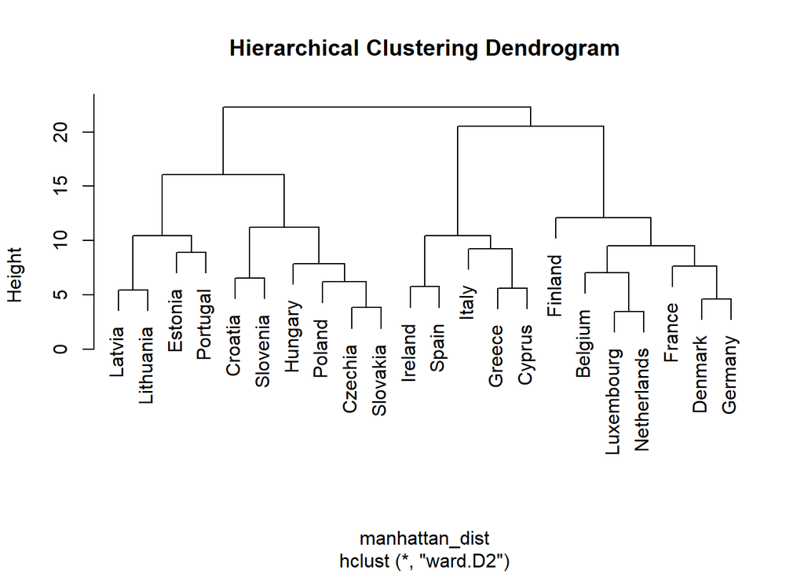

```r
hc1 <- hclust(manhattan_dist, method = "ward.D2")
plot(hc1, main = "Hierarchical Clustering Dendrogram", labels = roll$Country)
```

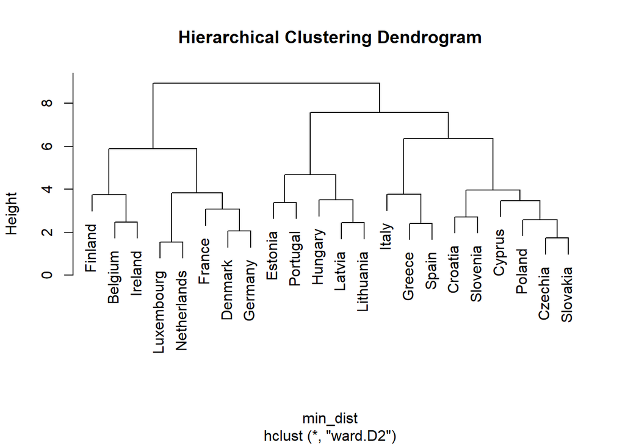

```r
min_dist <- dist(my_ds, method="minkowski", p=2)
hc2 <- hclust(min_dist, method = "ward.D2")
plot(hc2, main = "Hierarchical Clustering Dendrogram", labels = roll$Country)
```

```r
# we calculate the rankings
grad_eu<-order(dist_matrix)
# let's define a new object of type dist equal to the distance matrix
order_eu<- dist_matrix
# now we're going to fill it with the rankings
for(i in 1:length(grad_eu)) {
    order_eu[grad_eu[i]]<-i
}
order_eu
```

```
##      1   2   3   4   5   6   7   8   9  10  11  12  13  14  15  16  17  18  19
## 2  142
## 3   68 102
## 4   89  25   4
## 5   75 123  48  26
## 6    9  86  65  93 106
## 7  128 121 213 182 203  72
## 8   29  84 173 119 129  12   7
## 9  122 125  53   5  62 168 191 163
## 10 118  42 149  30  95 171  91  78  19
## 11  98 178 216 193 201 148  46  64 155 104
## 12 180  10 152  74 189  79  28  55 107  73 109
## 13 225  99 185  94  71 228 208 218 108  32 204 157
## 14 187  37 117  47  21 177 179 141 146  44 220 145   8
## 15  45 153  43  51  92 110 210 175  27 132  67 144 198 215
## 16 207  23 126  66 136 158 170 184 156  58 226  77  61  22 217
## 17  35 101   6  13  59  76 211 165  38 138 127 139 190 176   1 199
## 18 197   3 154  90 202 192 206 183 188  70 205  97 114  83 186  60 130
## 19 161 112 140  40  49 194 227 174  56  80 200 169  88  85 105 134 115 164
## 20 111  14 133  31 143 135 120  57  50  15  96  41 150 131 103 172  82  36 116
## 21 181   2 160  69 113 124  52  63 137  20 147  11  39  16 196  33 162  17 151
## 22  81 167  18 100  87  34 223 166 214 229 230 219 231 195 159 224  54 221 222
##     20  21
## 2
## 3
## 4
## 5
## 6
## 7
## 8
## 9
## 10
## 11
## 12
## 13
## 14
## 15
## 16
## 17
## 18
## 19
## 20
## 21  24
## 22 209 212
```

```r
clu <- cutree(hc, k =5)
clu
```

```
##  [1] 1 2 3 3 4 1 5 5 3 2 5 2 4 4 3 4 3 2 4 2 2 1
```

```r
table(clu)
```

```
## clu
## 1 2 3 4 5
## 3 6 5 5 3
```

```r
 str(as.dendrogram(hc))
```

```
## --[dendrogram w/ 2 branches and 22 members at h = 8.92]
##   |--[dendrogram w/ 2 branches and 8 members at h = 5.87]
##   |  |--[dendrogram w/ 2 branches and 3 members at h = 3.73]
##   |  |  |--leaf 22
##   |  |  `--[dendrogram w/ 2 branches and 2 members at h = 2.46]
##   |  |     |--leaf 1
##   |  |     `--leaf 6
##   |  `--[dendrogram w/ 2 branches and 5 members at h = 3.83]
##   |     |--[dendrogram w/ 2 branches and 2 members at h = 1.54]
##   |     |  |--leaf 15
##   |     |  `--leaf 17
##   |     `--[dendrogram w/ 2 branches and 3 members at h = 3.07]
##   |        |--leaf 9
##   |        `--[dendrogram w/ 2 branches and 2 members at h = 2.05]
##   |           |--leaf 3
##   |           `--leaf 4
##   `--[dendrogram w/ 2 branches and 14 members at h = 7.56]
##      |--[dendrogram w/ 2 branches and 5 members at h = 4.67]
##      |  |--[dendrogram w/ 2 branches and 2 members at h = 3.38]
##      |  |  |--leaf 5
##      |  |  `--leaf 19
##      |  `--[dendrogram w/ 2 branches and 3 members at h = 3.5]
##      |     |--leaf 16
##      |     `--[dendrogram w/ 2 branches and 2 members at h = 2.44]
##      |        |--leaf 13
##      |        `--leaf 14
##      `--[dendrogram w/ 2 branches and 9 members at h = 6.35]
##         |--[dendrogram w/ 2 branches and 3 members at h = 3.76]
##         |  |--leaf 11
##         |  `--[dendrogram w/ 2 branches and 2 members at h = 2.41]
##         |     |--leaf 7
##         |     `--leaf 8
##         `--[dendrogram w/ 2 branches and 6 members at h = 3.96]
##            |--[dendrogram w/ 2 branches and 2 members at h = 2.7]
##            |  |--leaf 10
##            |  `--leaf 20
##            `--[dendrogram w/ 2 branches and 4 members at h = 3.46]
##               |--leaf 12
##               `--[dendrogram w/ 2 branches and 3 members at h = 2.58]
##                  |--leaf 18
##                  `--[dendrogram w/ 2 branches and 2 members at h = 1.73]
##                     |--leaf 2
##                     `--leaf 21
```

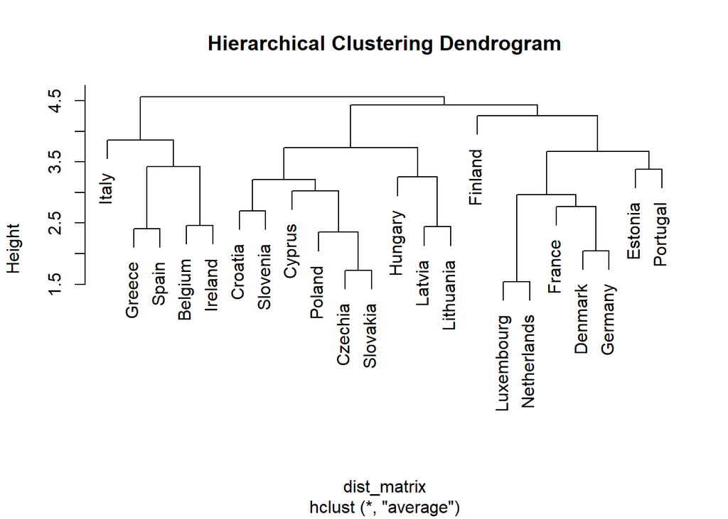

```r
h4 <- hclust(dist_matrix, method="average")
plot(h4, main = "Hierarchical Clustering Dendrogram", labels = roll$Country)
```

Similarities indices to see which countries are most similar to each other

```r
# Gower's index
simil(my_ds, method="Gower")
```

```
##            1         2         3         4         5         6         7
## 2  0.6092645
## 3  0.7370386 0.7306748
## 4  0.7391908 0.7627121 0.8591373
## 5  0.7278790 0.6710111 0.7291324 0.7620604
## 6  0.8177058 0.6997744 0.7451756 0.7276230 0.6757005
## 7  0.6679419 0.7064401 0.5842211 0.6338879 0.5793256 0.7318149
## 8  0.7634933 0.7289966 0.6701831 0.6921294 0.6255405 0.8327538 0.7916181
## 9  0.7494834 0.6562923 0.7578635 0.8245111 0.7192331 0.6500708 0.6377240
## 10 0.6642573 0.7601881 0.6914164 0.7620427 0.7589244 0.5802790 0.7022691
## 11 0.6767333 0.6868420 0.5996494 0.5979970 0.5961282 0.6691379 0.7587463
## 12 0.6468137 0.7963589 0.6757907 0.7567649 0.5749018 0.7375342 0.8282829
## 13 0.5625132 0.6637055 0.5756476 0.6741699 0.7170238 0.5368154 0.5737381
## 14 0.6082685 0.7374699 0.6669895 0.7531825 0.7745785 0.6818595 0.6352433
## 15 0.7982413 0.6358919 0.7803079 0.7879826 0.6995456 0.7395842 0.5679988
## 16 0.5660376 0.7968324 0.6548348 0.7213234 0.6922699 0.6477903 0.6687832
## 17 0.8055367 0.6692950 0.8496352 0.8160471 0.7119349 0.7180621 0.5614312
## 18 0.5829127 0.8587002 0.6779157 0.7208859 0.6608963 0.6330995 0.6163940
## 19 0.6535775 0.6658068 0.7243040 0.7636061 0.7285970 0.6023679 0.5414092
## 20 0.7133035 0.7879030 0.7250617 0.7828437 0.6576223 0.6631394 0.6883784
## 21 0.5817664 0.8833050 0.6521052 0.7395849 0.7020304 0.6457807 0.7355416
## 22 0.7007943 0.6511722 0.7938488 0.7035861 0.6887779 0.7565989 0.5826736
##            8         9        10        11        12        13        14
## 2
## 3
## 4
## 5
## 6
## 7
## 8
## 9  0.6547738
## 10 0.6867799 0.7666111
## 11 0.7816472 0.6314378 0.6725977
## 12 0.7569768 0.7430967 0.7215045 0.7155125
## 13 0.5518632 0.7244339 0.7223146 0.5586903 0.6577016
## 14 0.6615115 0.6351620 0.7131133 0.5574285 0.6688331 0.8304771
## 15 0.6330455 0.7673602 0.6287856 0.7455263 0.6981578 0.6073810 0.5856611
## 16 0.6300229 0.6147248 0.7299041 0.5584974 0.6902555 0.7194583 0.8133571
## 17 0.6358531 0.7748146 0.6415627 0.6691283 0.6862675 0.6175128 0.6028249
## 18 0.6273598 0.6075092 0.7398157 0.5995346 0.6860060 0.6827788 0.7295295
```

[output cut: 11 more lines]

```
## 8
## 9
## 10
## 11
## 12
## 13
## 14
## 15
## 16 0.5427371
## 17 0.8931841 0.5761403
## 18 0.6029818 0.7937410 0.6522580
## 19 0.7067588 0.6171601 0.7245866 0.6272645
## 20 0.7139191 0.6345631 0.7399239 0.7563077 0.6822022
## 21 0.5884542 0.7855612 0.6039087 0.8124482 0.6205964 0.7644608
## 22 0.6527370 0.5948759 0.7462313 0.5815559 0.5592389 0.6505613 0.5881171
```

```r
my_ds_sub <-my_ds[,-c(1,2,3,4,5,6)]
rownames(my_ds_sub)<-roll$Country
```